# SPRITE

Ian Hussey

```r
library(tidyverse)
library(janitor)
library(rsprite2)
library(knitr)
library(kableExtra)

min_decimals <- function(x, digits = 2) {
  sprintf(paste0("%.", digits, "f"), x)
}
```

# SPRITE

Note that data is hard coded into the RMarkdown file. It could also be loaded from disk, e.g., from a correctly formatted .csv file (with the headers label, mean, sd, n, and items) to a tibble via readr::read_csv().

Note that datasets are only generated using the first row of the summary_statistics dataframe. You can alter the code below to change which row is used.

```r
# enter your data here. Here is some example data
summary_statistics <-
  tibble(
    label = c("age group 1", "age group 2", "age group 2"),
    mean  = c(31.09,         20.70,         31.92),
    sd    = c(6.03,          3.40,          4.83),
    n     = c(23,            23,            29),
    items = c(1,             1,             1) # number of items in the scale used to measure this variable. For a single item measure like "what is your age?", items = 1. For a multi item scale, e.g., the BDI-II, this would be the number of items (e.g., 21).
  ) |>
  # these conversions to character and, below, back to numeric are done because the code is also common to the GRIM and GRIMMER tests, which require character data.
  mutate(x = as.character(min_decimals(mean)),
         sd = as.character(min_decimals(sd)))

# summary statistics to generate data from
# note that when the summary_statistics data frame has multiple rows, only the first is used. Alter the code here to change this behavior, e.g., from [1] to [2].
sprite_parameters <-
  set_parameters(mean = summary_statistics$mean[1],
                 m_prec = 2, # number of decimal place M was reported to
                 sd = as.numeric(summary_statistics$sd[1]),
                 sd_prec = 2, # number of decimal place SD was reported to
                 n_obs = summary_statistics$n[1],
                 min_val = 18, # lowest possible value of variable, if applicable. Eg. age could not be less than 18
                 max_val = 120)  # highest possible value of variable, if applicable. Eg. age unlikely to be above 120

# generate data
sprite_results <-
  find_possible_distributions(sprite_parameters,
                              seed = 42, # set seed for random number generator for reproducibility
                              n_distributions = 100)
```

## Plot type 1

Useful to see the min and max scores that could generate the summary statistics. Harder to interpret multimodality.

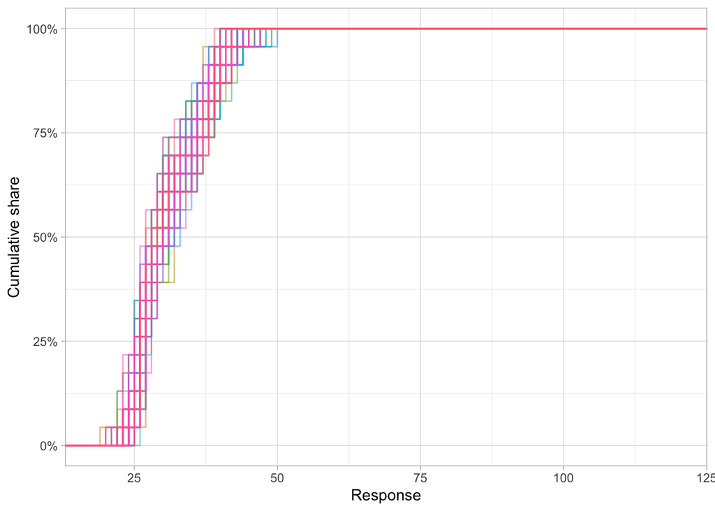

```r
plot_distributions(sprite_results)
```